# MLA

Primary Findings

Mark Russeff, Renato Albolea, Shuai Ma

# 1. Abstract

# 2. Background

The following abstract appeared in Alicia H. Munnell, Geoffrey M.B. Tootell, Lynn E. Browne, and James McEneaney (1996), “Mortgage Lending in Boston: Interpreting HMDA Data,” American Economic Review 86, 25-53.

> *The Home Mortgage Disclosure Act was enacted to monitor minority and low-income access to the mortgage market. The data collected for this purpose show that minorities are more than twice as likely to be denied a mortgage as whites. Yet variables correlated with both race and creditworthiness were omitted from these data, making any conclusion about race’s role in mortgage lending impossible. The Federal Reserve Board of Boston collected* additional variables important to the mortgage lending decision….

As discussed in Munnell et al (1996), the HMDA data indicate whether an applicant’s mortgage application was approved and provide several demographic characteristics. In 1990, following the request of the Federal Reserve Board of Boston, lending institutions in the Boston area provided additional information relevant to mortgage lending decisions. In light of the relatively small number of mortgage loan applications made by minorities, these extra variables were collected for all applications by blacks and Hispanics and for a random sample of those by whites.

> *All applicants are non-Hispanic white, non Hispanic black, or Hispanic. [In 1990 about 94% of Boston residents were white, Black, or Hispanic.](http://www.bostonplans.org/getattachment/83972a7a-c454-4aac-b3eb-02e1fddd71e3/)*

# 3. Research Question

- **Controlling for relevant characteristics, is race/ethnicity associated with the outcome of a mortgage loan application?**

# 4. Explortory Data Analysis

## 4.1 Data Wrangling

**(A) First View of Data** (The code and result are hid here since this is not key point of this paper, and makes this paper clean. The final data summary will be showed.)

1. First Thought:
- The following column names should be updated:
  - GDLIN - Credit_History (credit history meets the guideline)
  - OBRAT - Other_Obligations (other obligations as a percent of total income)
  - LOANPRC - Loan_Percentage (loan amount/purchase price)
- The following variables should be changed to factors:
  - MARRIED
  - GDLIN
  - BLACK
  - HISPAN
  - MALE
  - APPROVE

**(B) Second View of Data** (Code and results are hid.)

2. Second Thought (criteria for sub-setting data ):
- Remove the three “.” from “Married”
- Remove the two “666” from “Credit_History”
- Remove the fifteen “.” from “Male”
- Remove the value which higher than 1 from “Loan_Percentage”

**(C) Final Data Summary**

```r
summary(base)
```

```
##  Married  Credit_History Other_Obligations Black    Hispan   Male
##  0: 662   0: 167         Min.   : 0.00     0:1745   0:1833   0: 361
##  1:1275   1:1770         1st Qu.:28.00     1: 192   1: 104   1:1576
##                          Median :33.00
##                          Mean   :32.37
##                          3rd Qu.:37.00
##                          Max.   :95.00
##  Approve  Loan_Percentage
##  0: 235   Min.   :0.02105
##  1:1702   1st Qu.:0.69697
##           Median :0.80000
##           Mean   :0.76075
##           3rd Qu.:0.89820
##           Max.   :1.00000
```

## 4.2 Race and Gender

(Code is hid from this paper, but available based on request)

**Findings from race and gender:**

| Total Number by Race and Gender | Total Number by Race and Gender Gender | Total Number by Race and Gender Black | Total Number by Race and Gender Hispan | Total Number by Race and Gender Not Hispan/Black | Total Number by Race and Gender Total |
| --- | --- | --- | --- | --- | --- |
| 1 | Female | 50 | 20 | 291 | 361 |
| 2 | Male | 142 | 84 | 1350 | 1576 |
| 3 | Total | 192 | 104 | 1641 | 1937 |

| Percentage by Race and Gender | Percentage by Race and Gender Gender | Percentage by Race and Gender Black | Percentage by Race and Gender Hispan | Percentage by Race and Gender Not Hispan/Black | Percentage by Race and Gender Total |
| --- | --- | --- | --- | --- | --- |
| 1 | Female | 2.6% | 1.0% | 15.0% | 18.6% |
| 2 | Male | 7.3% | 4.3% | 69.7% | 81.4% |
| 3 | Total | 9.9% | 5.4% | 84.7% | 100.0% |

## 4.3 Race and Approval

(Code is hid from this paper, but available based on request)

**Findings from race and decision:**

1. Among all applicants the approved application from Black counts for 6.6%. The approval rate for applications from Black was **66.7%**.
2. Among all applicants the approved application from Hispanic counts for 4.2%. The approval rate for applications from Hispanic was **77.9%**.
3. Among all applicants the approved application from Non-Black/Hispanic counts for 77.1%.The approval rate for applications from Non-Blackwas **91.0%**.
4. The average approval rate was **87.9%**.

| Total Number by Race and Decision | Total Number by Race and Decision Approve | Total Number by Race and Decision Black | Total Number by Race and Decision Hispan | Total Number by Race and Decision Not Hispan/Black | Total Number by Race and Decision Total |
| --- | --- | --- | --- | --- | --- |
| 1 | Approved | 128 | 81 | 1493 | 1702 |
| 2 | Denied | 64 | 23 | 148 | 235 |
| 3 | Total | 192 | 104 | 1641 | 1937 |

| Percentage by Race and Decision | Percentage by Race and Decision Approve | Percentage by Race and Decision Black | Percentage by Race and Decision Hispan | Percentage by Race and Decision Not Hispan/Black | Percentage by Race and Decision Total |
| --- | --- | --- | --- | --- | --- |
| 1 | Approved | 6.6% | 4.2% | 77.1% | 87.9% |
| 2 | Denied | 3.3% | 1.2% | 7.6% | 12.1% |
| 3 | Total | 9.9% | 5.4% | 84.7% | 100.0% |

## 4.4 Race and Credit History

(Code is hid from this paper, but available based on request)

**Findings from race and credit history:**

| Total Number by Race and Credit History | Total Number by Race and Credit History Credit_History | Total Number by Race and Credit History Black | Total Number by Race and Credit History Hispan | Total Number by Race and Credit History Not Hispan/Black | Total Number by Race and Credit History Total |
| --- | --- | --- | --- | --- | --- |
| 1 | Good | 139 | 90 | 1541 | 1770 |
| 2 | Not Good | 53 | 14 | 100 | 167 |
| 3 | Total | 192 | 104 | 1641 | 1937 |

| Percentage by Race and Credit History | Percentage by Race and Credit History Credit_History | Percentage by Race and Credit History Black | Percentage by Race and Credit History Hispan | Percentage by Race and Credit History Not Hispan/Black | Percentage by Race and Credit History Total |
| --- | --- | --- | --- | --- | --- |
| 1 | Good | 7.2% | 4.6% | 79.6% | 91.4% |
| 2 | Not Good | 2.7% | 0.7% | 5.2% | 8.6% |
| 3 | Total | 9.9% | 5.4% | 84.7% | 100.0% |

## 4.5 Race, Credit History, Decision

**Findings from race, credit history, and decision:**

1. Among all applicants who were with “Good” credit history, the approval rate was **“Not Hispan/Black” > “Black” > “Hispan”**.
2. Among all applicants who were with “Not Good” credit history, the approval rate was **“Not Hispan/Black” > “Hispan” > “Black”**.

**(A)Approveal/Denial Rate with Good Credit History by Races**

| Approval Rate by Race and Credit History - Black with Good Credit | Approval Rate by Race and Credit History - Black with Good Credit Category | Approval Rate by Race and Credit History - Black with Good Credit Decision | Approval Rate by Race and Credit History - Black with Good Credit Counts | Approval Rate by Race and Credit History - Black with Good Credit Rate |
| --- | --- | --- | --- | --- |
| 1 | Black - Good | Approved | 122 | 0.878 |
| 2 | Black - Good | Denied | 17 | 0.122 |

| Approval Rate by Race and Credit History - Hispan with Good Credit | Approval Rate by Race and Credit History - Hispan with Good Credit Category | Approval Rate by Race and Credit History - Hispan with Good Credit Decision | Approval Rate by Race and Credit History - Hispan with Good Credit Counts | Approval Rate by Race and Credit History - Hispan with Good Credit Rate |
| --- | --- | --- | --- | --- |
| 1 | Hispan - Good | Approved | 78 | 0.867 |
| 2 | Hispan - Good | Denied | 12 | 0.133 |

[output not shown]

**(B)Approveal/Denial Rate with Not Good Credit History by Races**

| Approval Rate by Race and Credit History - Black with Not Good Credit | Approval Rate by Race and Credit History - Black with Not Good Credit Category | Approval Rate by Race and Credit History - Black with Not Good Credit Decision | Approval Rate by Race and Credit History - Black with Not Good Credit Counts | Approval Rate by Race and Credit History - Black with Not Good Credit Rate |
| --- | --- | --- | --- | --- |
| 1 | Black - Not Good | Approved | 6 | 0.113 |
| 2 | Black - Not Good | Denied | 47 | 0.887 |

[output not shown]

[output not shown]

## 4.6 Distribution of loan rate

- loan rate = loan amount / purchase price

**Findings from distribution of loan rate by races and genders:**

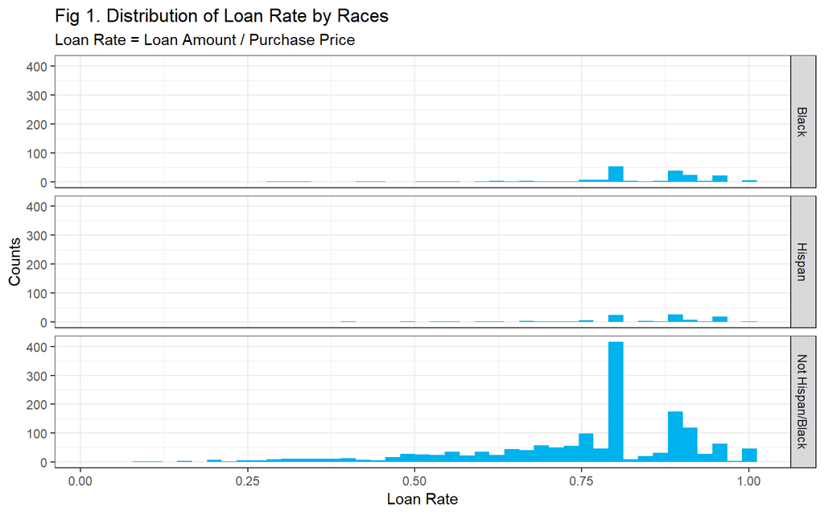

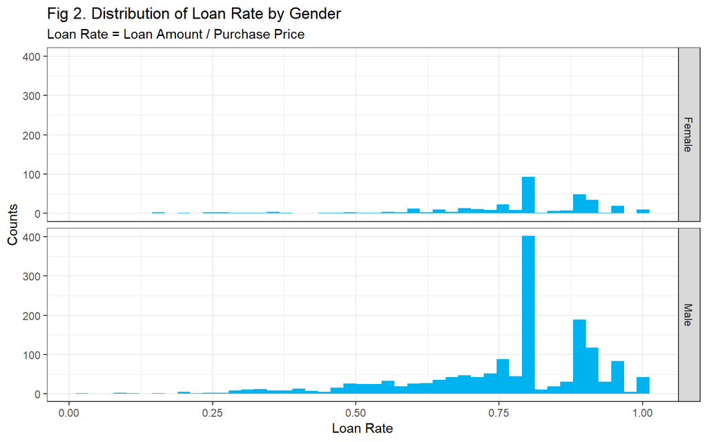

# 5. Estimating Models

## 5.1 Model considering Race

**(A) Estimate Logit Model**

```r
LogitModel = glm(Approve ~ Other_Obligations + Black + Hispan, data = base , family = "binomial")
summary(LogitModel)
```

```
##
## Call:
## glm(formula = Approve ~ Other_Obligations + Black + Hispan, family = "binomial",
##     data = base)
##
## Deviance Residuals:
##     Min       1Q   Median       3Q      Max
## -2.7391   0.3497   0.4190   0.4759   1.6139
##
## Coefficients:
##                    Estimate Std. Error z value Pr(>|z|)
## (Intercept)        4.102332   0.308835  13.283  < 2e-16 ***
## Other_Obligations -0.053552   0.008528  -6.280 3.39e-10 ***
## Black1            -1.503975   0.179092  -8.398  < 2e-16 ***
## Hispan1           -1.004770   0.256139  -3.923 8.75e-05 ***
## ---
## Signif. codes:  0 '***' 0.001 '**' 0.01 '*' 0.05 '.' 0.1 ' ' 1
##
## (Dispersion parameter for binomial family taken to be 1)
##
##     Null deviance: 1431.6  on 1936  degrees of freedom
## Residual deviance: 1308.4  on 1933  degrees of freedom
## AIC: 1316.4
##
## Number of Fisher Scoring iterations: 5
```

**The signals of the model suggest that:**

1. Increases in Other Obligation diminish the likelihood of approval of the loan, which makes sense.
2. Being Black or Hispanic diminish your likelihood of approval of the loan, which does not make sense (your ethnicity does not interfere to your capacity to pay a loan), but was expected.

**(B) Generate Odds Ratios**

```r
exp(coef(LogitModel))
```

```
##       (Intercept) Other_Obligations            Black1           Hispan1
##        60.4811395         0.9478570         0.2222449         0.3661287
```

**The Odd ratios suggest that:**

1. White people had 4.5 times the odds of being approved for a loan as a black person;(p<0.01)
2. White people had 2.73 times the odds of being approved for a loan as a Hispanic person;(p<0.01)
3. One unit of increase in other obligations reduce in 5.21 percentage the odds of being approved for a loan in ;(p<0.01)

**(C) Define prototypical loan applicants (you will need more than 3)**

```r
prototype_black <- data.frame(Other_Obligations=mean(base$Other_Obligations),Black = 1, Hispan = 0)
prototype_black <-prototype_black %>% mutate(Black = as.factor(Black),
                                             Hispan = as.factor(Hispan))
# levels(prototype_black$Black) <- "Black"
# levels(prototype_black$Hispan) <- NA

prototype_hisp <- data.frame(Other_Obligations=mean(base$Other_Obligations),Black = 0, Hispan = 1)
prototype_hisp <-prototype_hisp %>% mutate(Black = as.factor(Black),
                                             Hispan = as.factor(Hispan))
# levels(prototype_hisp$Black) <- NA
# levels(prototype_hisp$Hispan) <- "Hispan"

prototype_white <- data.frame(Other_Obligations=mean(base$Other_Obligations),Black = 0, Hispan = 0)
prototype_white <-prototype_white %>% mutate(Black = as.factor(Black),
                                             Hispan = as.factor(Hispan))
# levels(prototype_white$Black) <- NA
# levels(prototype_white$Hispan) <- NA
```

**(D) Predict probabilities for prototypical individuals**

```r
prototype_black$predictedprob <- round(
  predict (LogitModel,
           newdata = prototype_black,
           type ="response")*100,
  digits = 1)


prototype_hisp$predictedprob <-  round(
  predict (LogitModel,
           newdata = prototype_hisp,
           type ="response")*100,
  digits = 1)
prototype_white$predictedprob <- round(
  predict (LogitModel,
           newdata = prototype_white,
           type ="response")*100,
  digits = 1)
```

**(D-1) Predict probabilities for prototypical individuals - Black**

```r
prototype_black
```

| Other_Obligations | Black | Hispan | predictedprob |
| --- | --- | --- | --- |
| 32.36561 | 1 | 0 | 70.4 |

**(D-2) Predict probabilities for prototypical individuals - Hispan**

```r
prototype_hisp
```

| Other_Obligations | Black | Hispan | predictedprob |
| --- | --- | --- | --- |
| 32.36561 | 0 | 1 | 79.6 |

**(D-3) Predict probabilities for prototypical individuals - White**

```r
prototype_white
```

| Other_Obligations | Black | Hispan | predictedprob |
| --- | --- | --- | --- |
| 32.36561 | 0 | 0 | 91.4 |

We can see that White man with % of other obligations has 91.4% of chances to be approved for a loan. At the same situation, black people have, for the same situation only 70.4% of chances to be approved for a loan and Hispanics have only 79.6% of chances to be approved for a loan.

**(E) Estimate Probit Model**

```r
ProbitModel = glm(Approve ~ Other_Obligations + Black + Hispan, data = base,
                  family = "binomial" (link = "probit"))
summary(ProbitModel)
```

```
##
## Call:
## glm(formula = Approve ~ Other_Obligations + Black + Hispan, family = binomial(link = "probit"),
##     data = base)
##
## Deviance Residuals:
##     Min       1Q   Median       3Q      Max
## -2.7853   0.3509   0.4227   0.4790   1.4023
##
## Coefficients:
##                    Estimate Std. Error z value Pr(>|z|)
## (Intercept)        2.227906   0.162911  13.676  < 2e-16 ***
## Other_Obligations -0.026830   0.004644  -5.778 7.56e-09 ***
## Black1            -0.848779   0.104508  -8.122 4.60e-16 ***
## Hispan1           -0.538181   0.145827  -3.691 0.000224 ***
## ---
## Signif. codes:  0 '***' 0.001 '**' 0.01 '*' 0.05 '.' 0.1 ' ' 1
##
## (Dispersion parameter for binomial family taken to be 1)
##
##     Null deviance: 1431.6  on 1936  degrees of freedom
## Residual deviance: 1311.5  on 1933  degrees of freedom
## AIC: 1319.5
##
## Number of Fisher Scoring iterations: 5
```

**The signals of the model suggest that:**

1. Increases in Other Obligation diminish the likelihood of approval of the loan, which makes sense.
2. Being Black or Hispanic diminish your likelihood of approval of the loan, which does not make sense (your ethnicity does not interfere to your capacity to pay a loan), but was expected.

**(F) Predict probabilities for prototypical individuals**

```r
prototype_black$predictedprob <- round(
  predict (ProbitModel,
           newdata = prototype_black,
           type ="response")*100,
  digits = 1)
prototype_hisp$predictedprob <-  round(
  predict (ProbitModel,
           newdata = prototype_hisp,
           type ="response")*100,
  digits = 1)
prototype_white$predictedprob <- round(
  predict (ProbitModel,
           newdata = prototype_white,
           type ="response")*100,
  digits = 1)
```

**(F-1) Predict probabilities for prototypical individuals - Black**

```r
prototype_black
```

| Other_Obligations | Black | Hispan | predictedprob |
| --- | --- | --- | --- |
| 32.36561 | 1 | 0 | 69.5 |

**(F-2) Predict probabilities for prototypical individuals - Hispan**

```r
prototype_hisp
```

| Other_Obligations | Black | Hispan | predictedprob |
| --- | --- | --- | --- |
| 32.36561 | 0 | 1 | 79.4 |

**(F-3) Predict probabilities for prototypical individuals - White**

```r
prototype_white
```

| Other_Obligations | Black | Hispan | predictedprob |
| --- | --- | --- | --- |
| 32.36561 | 0 | 0 | 91.3 |

We can see that White man with 32.37% of other obligations has 91.3% of chances to be approved for a loan. At the same situation, black people have, for the same situation only 69.5% of chances to be approved for a loan and Hispanics have only 79.4% of chances to be approved for a loan.  
The results are consistent between both models.

## 5.2 Model considering Gender

**(A) Estimate Logit Model**

```r
LogitModel = glm(Approve ~ Other_Obligations + Male, data = base,
                 family = "binomial")
summary(LogitModel)
```

```
##
## Call:
## glm(formula = Approve ~ Other_Obligations + Male, family = "binomial",
##     data = base)
##
## Deviance Residuals:
##     Min       1Q   Median       3Q      Max
## -2.6971   0.3912   0.4779   0.5348   1.9165
##
## Coefficients:
##                    Estimate Std. Error z value Pr(>|z|)
## (Intercept)        3.910538   0.337325  11.593  < 2e-16 ***
## Other_Obligations -0.059923   0.008496  -7.053 1.75e-12 ***
## Male1              0.119326   0.176489   0.676    0.499
## ---
## Signif. codes:  0 '***' 0.001 '**' 0.01 '*' 0.05 '.' 0.1 ' ' 1
##
## (Dispersion parameter for binomial family taken to be 1)
##
##     Null deviance: 1431.6  on 1936  degrees of freedom
## Residual deviance: 1378.3  on 1934  degrees of freedom
## AIC: 1384.3
##
## Number of Fisher Scoring iterations: 5
```

**(B) Generate Odds Ratios**

```r
exp(coef(LogitModel))
```

```
##       (Intercept) Other_Obligations             Male1
##        49.9258045         0.9418374         1.1267374
```

**(C) Define prototypical loan applicants**

```r
prototype_woman <- data.frame(Other_Obligations=mean(base$Other_Obligations),Male = 0)
prototype_woman <-prototype_woman %>% mutate(Male = as.factor(Male))
# levels(prototype_woman$Male) <- "Female"
prototype_men <- data.frame(Other_Obligations=mean(base$Other_Obligations),Male = 1)
prototype_men <- prototype_men %>% mutate(Male = as.factor(Male))
# levels(prototype_men$Male) <- "Male"
#Predict probabilities for prototypical individuals
prototype_woman$predictedprob <- round(
  predict (LogitModel,
           newdata = prototype_woman,
           type ="response")*100,
  digits = 1)


prototype_men$predictedprob <-  round(
  predict (LogitModel,
           newdata = prototype_men,
           type ="response")*100,
  digits = 1)
```

**(C-1) Define prototypical loan applicants - Female**

```r
prototype_woman
```

| Other_Obligations | Male | predictedprob |
| --- | --- | --- |
| 32.36561 | 0 | 87.8 |

**(C-2) Define prototypical loan applicants - Male**

```r
prototype_men
```

| Other_Obligations | Male | predictedprob |
| --- | --- | --- |
| 32.36561 | 1 | 89 |

Both Man and Woman have the similar probabilities of being approved for a loan considering they have 32.37% of other obligation

**(D) Estimate Probit Model**

```r
ProbitModel = glm(Approve ~ Other_Obligations + Male , data = base,
                  family = "binomial" (link = "probit"))
summary(ProbitModel)
```

```
##
## Call:
## glm(formula = Approve ~ Other_Obligations + Male, family = binomial(link = "probit"),
##     data = base)
##
## Deviance Residuals:
##     Min       1Q   Median       3Q      Max
## -2.7309   0.3967   0.4839   0.5384   1.6647
##
## Coefficients:
##                    Estimate Std. Error z value Pr(>|z|)
## (Intercept)        2.134905   0.177894  12.001  < 2e-16 ***
## Other_Obligations -0.030125   0.004577  -6.582 4.65e-11 ***
## Male1              0.052976   0.094495   0.561    0.575
## ---
## Signif. codes:  0 '***' 0.001 '**' 0.01 '*' 0.05 '.' 0.1 ' ' 1
##
## (Dispersion parameter for binomial family taken to be 1)
##
##     Null deviance: 1431.6  on 1936  degrees of freedom
## Residual deviance: 1381.7  on 1934  degrees of freedom
## AIC: 1387.7
##
## Number of Fisher Scoring iterations: 5
```

**(E) Predict probabilities for prototypical individuals**

```r
prototype_woman$predictedprob <- round(
  predict (ProbitModel,
           newdata = prototype_woman,
           type ="response")*100,
  digits = 1)
prototype_men$predictedprob <-  round(
  predict (ProbitModel,
           newdata = prototype_men,
           type ="response")*100,
  digits = 1)
```

**(E-1) Predict probabilities for prototypical individuals - Female**

```r
prototype_woman
```

| Other_Obligations | Male | predictedprob |
| --- | --- | --- |
| 32.36561 | 0 | 87.7 |

**(E-2) Predict probabilities for prototypical individuals - Male**

```r
prototype_men
```

| Other_Obligations | Male | predictedprob |
| --- | --- | --- |
| 32.36561 | 1 | 88.7 |

The results are consistent between both models.